# Errors!

## Subseleccions

Ara volem agafar trossos de l’objecte. Això ho fem amb select i filter:

Imaginem que volem agafar només les dones (Female)

```r
liver %>%
  filter(Gender = Female)
```

```
## Error: Problem with `filter()` input `..1`.
## x Input `..1` is named.
## i This usually means that you've used `=` instead of `==`.
## i Did you mean `Gender == Female`?
```

Fixeu-vos que aquí l’error ja ens diu que potser ens hem deixat un igual una altra vegada! Efectivament:

```r
liver %>%
  filter(Gender == Female)
```

```
## Error: Problem with `filter()` input `..1`.
## x object 'Female' not found
## i Input `..1` is `Gender == Female`.
```

Object ‘Female’ not found; les cometes!!

```r
dones <- liver %>%
  filter(Gender == "Female")
```

Ara sí!

Ara volem seleccionar les variables Age, Gender i Total_bilirubin:

```r
liver %>%
  select(Age, Gender, Total_Bilirubin)
```

```
## # A tibble: 583 x 3
##      Age Gender Total_Bilirubin
##    <dbl> <chr>            <dbl>
##  1    65 Female             0.7
##  2    62 Male              10.9
##  3    62 Male               7.3
##  4    58 Male               1
##  5    72 Male               3.9
##  6    46 Male               1.8
##  7    26 Female             0.9
##  8    29 Female             0.9
##  9    17 Male               0.9
## 10    55 Male               0.7
## # ... with 573 more rows
```

Aquesta era fàcil.

Ara volem agafar tots els que siguin numèrics:

```r
liver %>%
  select(is.numeric)
```

```
## Warning: Predicate functions must be wrapped in `where()`.
##
##   # Bad
##   data %>% select(is.numeric)
##
##   # Good
##   data %>% select(where(is.numeric))
##
## i Please update your code.
## This message is displayed once per session.
```

```
## # A tibble: 583 x 9
##      Age Total_Bilirubin Direct_Bilirubin Alkaline_Phosphot~ Alamine_Aminotrans~
##    <dbl>           <dbl>            <dbl>              <dbl>               <dbl>
##  1    65             0.7              0.1                187                  16
##  2    62            10.9              5.5                699                  64
##  3    62             7.3              4.1                490                  60
##  4    58             1                0.4                182                  14
##  5    72             3.9              2                  195                  27
##  6    46             1.8              0.7                208                  19
##  7    26             0.9              0.2                154                  16
##  8    29             0.9              0.3                202                  14
##  9    17             0.9              0.3                202                  22
## 10    55             0.7              0.2                290                  53
## # ... with 573 more rows, and 4 more variables:
## #   Aspartate_Aminotransferase <dbl>, Total_Protiens <dbl>, Albumin <dbl>,
## #   Albumin_and_Globulin_Ratio <dbl>
```

Hem de fer:

```r
liver %>%
  select(where(is.numeric))
```

```
## # A tibble: 583 x 9
##      Age Total_Bilirubin Direct_Bilirubin Alkaline_Phosphot~ Alamine_Aminotrans~
##    <dbl>           <dbl>            <dbl>              <dbl>               <dbl>
##  1    65             0.7              0.1                187                  16
##  2    62            10.9              5.5                699                  64
##  3    62             7.3              4.1                490                  60
##  4    58             1                0.4                182                  14
##  5    72             3.9              2                  195                  27
##  6    46             1.8              0.7                208                  19
##  7    26             0.9              0.2                154                  16
##  8    29             0.9              0.3                202                  14
##  9    17             0.9              0.3                202                  22
## 10    55             0.7              0.2                290                  53
## # ... with 573 more rows, and 4 more variables:
## #   Aspartate_Aminotransferase <dbl>, Total_Protiens <dbl>, Albumin <dbl>,
## #   Albumin_and_Globulin_Ratio <dbl>
```

Un altre error típic en el seleccionar en una condició és fer:

```r
liver %>%
  select(where(is.numeric()))
```

```
## Error: 0 arguments passed to 'is.numeric' which requires 1
```

Quan fem aquests tipus de seleccions la funció de condició **no** porta parèntesis.

Filtres:

```r
liver %>%
  filter(Gender = Female)
```

```
## Error: Problem with `filter()` input `..1`.
## x Input `..1` is named.
## i This usually means that you've used `=` instead of `==`.
## i Did you mean `Gender == Female`?
```

Dos iguals, no un!

```r
liver %>%
  filter(Gender == Female)
```

```
## Error: Problem with `filter()` input `..1`.
## x object 'Female' not found
## i Input `..1` is `Gender == Female`.
```

Falten les cometes!

```r
liver %>%
  filter(Gender == "Female")
```

```
## # A tibble: 142 x 11
##      Age Gender Total_Bilirubin Direct_Bilirubin Alkaline_Phosphotase
##    <dbl> <chr>            <dbl>            <dbl>                <dbl>
##  1    65 Female             0.7              0.1                  187
##  2    26 Female             0.9              0.2                  154
##  3    29 Female             0.9              0.3                  202
##  4    74 Female             1.1              0.4                  214
##  5    40 Female             0.9              0.3                  293
##  6    40 Female             0.9              0.3                  293
##  7    84 Female             0.7              0.2                  188
##  8    38 Female             2.6              1.2                  410
##  9    38 Female             2.6              1.2                  410
## 10    17 Female             0.7              0.2                  145
## # ... with 132 more rows, and 6 more variables: Alamine_Aminotransferase <dbl>,
## #   Aspartate_Aminotransferase <dbl>, Total_Protiens <dbl>, Albumin <dbl>,
## #   Albumin_and_Globulin_Ratio <dbl>, Malaltia <chr>
```

Ara sí.

```r
liver %>%
  filter(c(Gender == "Female", Albumin > 3))
```

```
## Error: Problem with `filter()` input `..1`.
## x Input `..1` must be of size 583 or 1, not size 1166.
## i Input `..1` is `c(Gender == "Female", Albumin > 3)`.
```

Si tenim dues condicions, en aquest cas **no** hem de posar un vector, simplement anar-lies llistat:

```r
liver %>%
  filter(Gender == "Female", Albumin > 3)
```

```
## # A tibble: 88 x 11
##      Age Gender Total_Bilirubin Direct_Bilirubin Alkaline_Phosphotase
##    <dbl> <chr>            <dbl>            <dbl>                <dbl>
##  1    65 Female             0.7              0.1                  187
##  2    26 Female             0.9              0.2                  154
##  3    29 Female             0.9              0.3                  202
##  4    74 Female             1.1              0.4                  214
##  5    40 Female             0.9              0.3                  293
##  6    40 Female             0.9              0.3                  293
##  7    84 Female             0.7              0.2                  188
##  8    17 Female             0.7              0.2                  145
##  9    85 Female             1                0.3                  208
## 10    34 Female             0.6              0.1                  161
## # ... with 78 more rows, and 6 more variables: Alamine_Aminotransferase <dbl>,
## #   Aspartate_Aminotransferase <dbl>, Total_Protiens <dbl>, Albumin <dbl>,
## #   Albumin_and_Globulin_Ratio <dbl>, Malaltia <chr>
```

## Pivotacions

Imagineu que, per alguna raó, ara vull posar les edats dels homes i les dones cadascun en una columna; ho puc fer amb pivot_wider:

```r
temp <- liver %>% select(-Malaltia) %>%
  tidyr::pivot_wider(names_from = Gender, values_from = Age)
```

```
## Warning: Values are not uniquely identified; output will contain list-cols.
## * Use `values_fn = list` to suppress this warning.
## * Use `values_fn = length` to identify where the duplicates arise
## * Use `values_fn = {summary_fun}` to summarise duplicates
```

Fixeu-vos que no em dóna un error, però em dóna un warning i em diu que les "Values no estan únicament identificades). En aquest cas, el que passa és que les persones o són homes o són dones, per tant, en els que no siguin, tindré missings:

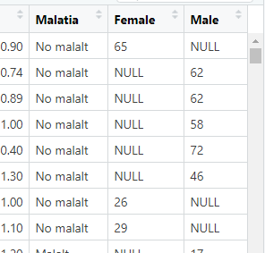

Fixeu-vos que no té sentit el que he fet per l’estructura que té el dataframe. Aquest és un exemple tonto però aquest warning passarà sovint i **sempre** l’hem de tenir en compte perquè vol dir que no hem fet el pivotatge que volíem fer i l’hem de pensar millor.

## Anàlisi estadístic

```r
t_student = t.test(liver$Gender)
```

```
## Warning in mean.default(x): argument is not numeric or logical: returning NA
```

```
## Warning in var(x): NAs introduced by coercion
```

```
## Error in if (stderr < 10 * .Machine$double.eps * abs(mx)) stop("data are essentially constant"): missing value where TRUE/FALSE needed
```

D’una forma una mica rebuscada, però em diu que què faig fent un t-test d’una variable categòrica; només es poden fer de variables contínues!

```r
t_student = t.test(liver$Total_Bilirubin, liver$Gender)
```

```
## Error in if (stderr < 10 * .Machine$double.eps * max(abs(mx), abs(my))) stop("data are essentially constant"): missing value where TRUE/FALSE needed
```

Aquest és un clàssic de quan ens confonem entre entrar les dades a un test d’hipòtesi en dos vectors o en una fórmula. Jo puc entrar la bilirrubina d’homes i dones com a dos vectors en un test t, així:

```r
# vector amb els valors dels homes
homes <- liver %>% filter(Gender == "Male") %>% pull(Total_Bilirubin)
# vector amb els valors de les dones
dones <- liver %>% filter(Gender == "Female") %>% pull(Total_Bilirubin)
# t-test amb dos vectors:
t.test(dones, homes)
```

```
##
##  Welch Two Sample t-test
##
## data:  dones and homes
## t = -2.5113, df = 319.39, p-value = 0.01252
## alternative hypothesis: true difference in means is not equal to 0
## 95 percent confidence interval:
##  -2.3017062 -0.2795272
## sample estimates:
## mean of x mean of y
##  2.322535  3.613152
```

Però la manera més natural de fer-ho serà:

```r
t.test(liver$Total_Bilirubin ~ liver$Gender)
```

```
##
##  Welch Two Sample t-test
##
## data:  liver$Total_Bilirubin by liver$Gender
## t = -2.5113, df = 319.39, p-value = 0.01252
## alternative hypothesis: true difference in means is not equal to 0
## 95 percent confidence interval:
##  -2.3017062 -0.2795272
## sample estimates:
## mean in group Female   mean in group Male
##             2.322535             3.613152
```

O més net encara:

```r
t.test(Total_Bilirubin ~ Gender, liver)
```

```
##
##  Welch Two Sample t-test
##
## data:  Total_Bilirubin by Gender
## t = -2.5113, df = 319.39, p-value = 0.01252
## alternative hypothesis: true difference in means is not equal to 0
## 95 percent confidence interval:
##  -2.3017062 -0.2795272
## sample estimates:
## mean in group Female   mean in group Male
##             2.322535             3.613152
```

## Models

```r
model = lm(Malaltia~.)
```

```
## Error in terms.formula(formula, data = data): '.' in formula and no 'data' argument
```

Tal com ens diu l’error, ens hem deixat les dades!

```r
model = lm(Malaltia~., data=liver)
```

```
## Error in lm.fit(x, y, offset = offset, singular.ok = singular.ok, ...): NA/NaN/Inf in 'y'
```

Ara ens diu que hi ha missings, infinits, que és tot un drama, vaja. Realment a vegades aquests errors no ens ajuden gaire, però ens està dient que estem posant una variable categòrica (Malaltia) com a variable dependent d’una regressió lineal, i per tant això no pot ser. Si volem una variable categòrica com a dependent, hem de fer una regressió logística:

```r
model = glm(Malaltia~., data=liver, family = "binomial")
```

```
## Error in eval(family$initialize): y values must be 0 <= y <= 1
```

Ja gairebé ho tenim això: y values han d’estar entre 0 i 1. Això vol dir que no troba la manera de categoritzar correctament la variable dependent, anem a mirar què passa:

```r
str(liver)
```

```
## spec_tbl_df [583 x 11] (S3: spec_tbl_df/tbl_df/tbl/data.frame)
##  $ Age                       : num [1:583] 65 62 62 58 72 46 26 29 17 55 ...
##  $ Gender                    : chr [1:583] "Female" "Male" "Male" "Male" ...
##  $ Total_Bilirubin           : num [1:583] 0.7 10.9 7.3 1 3.9 1.8 0.9 0.9 0.9 0.7 ...
##  $ Direct_Bilirubin          : num [1:583] 0.1 5.5 4.1 0.4 2 0.7 0.2 0.3 0.3 0.2 ...
##  $ Alkaline_Phosphotase      : num [1:583] 187 699 490 182 195 208 154 202 202 290 ...
##  $ Alamine_Aminotransferase  : num [1:583] 16 64 60 14 27 19 16 14 22 53 ...
##  $ Aspartate_Aminotransferase: num [1:583] 18 100 68 20 59 14 12 11 19 58 ...
##  $ Total_Protiens            : num [1:583] 6.8 7.5 7 6.8 7.3 7.6 7 6.7 7.4 6.8 ...
##  $ Albumin                   : num [1:583] 3.3 3.2 3.3 3.4 2.4 4.4 3.5 3.6 4.1 3.4 ...
##  $ Albumin_and_Globulin_Ratio: num [1:583] 0.9 0.74 0.89 1 0.4 1.3 1 1.1 1.2 1 ...
##  $ Malaltia                  : chr [1:583] "No malalt" "No malalt" "No malalt" "No malalt" ...
##  - attr(*, "spec")=
##   .. cols(
##   ..   Age = col_double(),
##   ..   Gender = col_character(),
##   ..   Total_Bilirubin = col_double(),
##   ..   Direct_Bilirubin = col_double(),
##   ..   Alkaline_Phosphotase = col_double(),
##   ..   Alamine_Aminotransferase = col_double(),
##   ..   Aspartate_Aminotransferase = col_double(),
##   ..   Total_Protiens = col_double(),
##   ..   Albumin = col_double(),
##   ..   Albumin_and_Globulin_Ratio = col_double(),
##   ..   Dataset = col_double()
##   .. )
```

Veiem que les variables Gender i Malaltia estan codificades com a caràcter i per tant no sap què fer amb elles! No ens hem currat prou la formatació abans de l’anàlisi i ara ens està tornant per destrossar-nos la vida. En fi, ho fem:

```r
liver <- liver %>%
  mutate(across(where(is.character), as.factor))
```

I ara:

```r
model = glm(Malaltia~., data=liver, family = "binomial")
```

```
## Warning: glm.fit: fitted probabilities numerically 0 or 1 occurred
```

Fixeu-vos que ara ens treu un warning: aquest warning vol dir que ha trobat un model perfecte i que és capaç de separar completament les dues mostres (malalts i no malalts). Això normalment vol dir que ens hem equivocat i hem posat alguna variable que és igual que la variable predita (per exemple, l’hem recodificat però ens hem oblidat l’antiga). Anem a veure el resultat del model per saber què ha passat:

```r
summary(model)
```

```
##
## Call:
## glm(formula = Malaltia ~ ., family = "binomial", data = liver)
##
## Deviance Residuals:
##     Min       1Q   Median       3Q      Max
## -3.1824  -1.0656   0.3756   0.9035   1.4550
##
## Coefficients:
##                              Estimate Std. Error z value Pr(>|z|)
## (Intercept)                -3.6046430  1.3296884  -2.711  0.00671 **
## Age                         0.0182922  0.0063783   2.868  0.00413 **
## GenderMale                  0.0309928  0.2328445   0.133  0.89411
## Total_Bilirubin             0.0112271  0.0869355   0.129  0.89724
## Direct_Bilirubin            0.4496843  0.2414926   1.862  0.06259 .
## Alkaline_Phosphotase        0.0012701  0.0008079   1.572  0.11594
## Alamine_Aminotransferase    0.0119298  0.0051001   2.339  0.01933 *
## Aspartate_Aminotransferase  0.0024729  0.0031198   0.793  0.42798
## Total_Protiens              0.9273824  0.3814252   2.431  0.01504 *
## Albumin                    -1.6951386  0.7480766  -2.266  0.02345 *
## Albumin_and_Globulin_Ratio  1.8080515  1.1408815   1.585  0.11302
## ---
## Signif. codes:  0 '***' 0.001 '**' 0.01 '*' 0.05 '.' 0.1 ' ' 1
##
## (Dispersion parameter for binomial family taken to be 1)
##
##     Null deviance: 692.01  on 578  degrees of freedom
## Residual deviance: 567.94  on 568  degrees of freedom
##   (4 observations deleted due to missingness)
## AIC: 589.94
##
## Number of Fisher Scoring iterations: 7
```

Sembla que el model té força sentit i no hi ha cap variable que ho predigui tot, així que, a priori, no fem cas del warning.

Models més avançats. Imagineu que volem fer servir la llibreria randomForests:

```r
forest = randomForest(Dataset~., data=liver)
```

```
## Error in randomForest(Dataset ~ ., data = liver): could not find function "randomForest"
```

L’hem de carregar primer (i assegureu-vos que l’heu instal·lat):

```r
# install.packages("randomForest")
library(randomForest)
```

L’anem a utilitzar:

```r
forest = randomForest(Malaltia~., data=liver)
```

```
## Error in na.fail.default(structure(list(Malaltia = structure(c(2L, 2L, : missing values in object
```

Ai ara a veure què passa; ho posem a l’[stackoverflow](https://stackoverflow.com/questions/41664317/randomforest-error-in-na-fail-default-missing-values-in-object):

Tinc missings! No he netejat bé!!

Investigo:

```r
summary(liver)
```

```
##       Age           Gender    Total_Bilirubin  Direct_Bilirubin
##  Min.   : 4.00   Female:142   Min.   : 0.400   Min.   : 0.100
##  1st Qu.:33.00   Male  :441   1st Qu.: 0.800   1st Qu.: 0.200
##  Median :45.00                Median : 1.000   Median : 0.300
##  Mean   :44.75                Mean   : 3.299   Mean   : 1.486
##  3rd Qu.:58.00                3rd Qu.: 2.600   3rd Qu.: 1.300
##  Max.   :90.00                Max.   :75.000   Max.   :19.700
##
##  Alkaline_Phosphotase Alamine_Aminotransferase Aspartate_Aminotransferase
##  Min.   :  63.0       Min.   :  10.00          Min.   :  10.0
##  1st Qu.: 175.5       1st Qu.:  23.00          1st Qu.:  25.0
##  Median : 208.0       Median :  35.00          Median :  42.0
##  Mean   : 290.6       Mean   :  80.71          Mean   : 109.9
##  3rd Qu.: 298.0       3rd Qu.:  60.50          3rd Qu.:  87.0
##  Max.   :2110.0       Max.   :2000.00          Max.   :4929.0
##
##  Total_Protiens     Albumin      Albumin_and_Globulin_Ratio      Malaltia
##  Min.   :2.700   Min.   :0.900   Min.   :0.3000             Malalt   :167
##  1st Qu.:5.800   1st Qu.:2.600   1st Qu.:0.7000             No malalt:416
##  Median :6.600   Median :3.100   Median :0.9300
##  Mean   :6.483   Mean   :3.142   Mean   :0.9471
##  3rd Qu.:7.200   3rd Qu.:3.800   3rd Qu.:1.1000
##  Max.   :9.600   Max.   :5.500   Max.   :2.8000
##                                  NA's   :4
```

Doncs sí, sembla que la variable Albumin_and_Globulin_Ratio té 4 missings. Per ara els trec (podeu mirar com tractar-los en la [classe de missings](https://github.com/ecorreig/analisi_dades_r/blob/main/sessio_extra_missings.Rmd)).

```r
liver <- liver %>% tidyr::drop_na()
```

A veure ara?

```r
forest = randomForest(Malaltia~., data=liver)
forest
```

```
##
## Call:
##  randomForest(formula = Malaltia ~ ., data = liver)
##                Type of random forest: classification
##                      Number of trees: 500
## No. of variables tried at each split: 3
##
##         OOB estimate of  error rate: 28.5%
## Confusion matrix:
##           Malalt No malalt class.error
## Malalt        55       110   0.6666667
## No malalt     55       359   0.1328502
```

Perfecte, tot bé!